# Wyniki egzaminów

2015.02.02

# Instalacja niezbędnych pakietów

Do wykonania ćwiczeń niezbędnę będą pakiety: *ZPD, ggplot2*, a także ich zależności (*dplyr, RPostgreSQL, reshape2, plyr*). Upewnijmy się więc, że wszystkie te pakiety posiadamy:

```r
install.packages(c('devtools', 'ggplot2', 'dplyr', 'RPostgreSQL', 'reshape2', 'plyr'))
devtools::install_github('zozlak/ZPD')
```

Załadujmy potrzebne pakiety i nawiążmy połączenie z bazą:

```r
library(ZPD)
library('ggplot2')

src = polacz()
```

# Czas pobierania danych

# Surowe wyniki egzaminacyjne

- W postaci *szerokiej* (takiej, do jakiej jesteśmy przyzwyczajeni):
  - `pobierz_wyniki_egzaminu(src, rodzajEgzaminu, czescEgzaminu, rokEgzaminu, czyEwd, punktuj, idSkali, skroc)`
    - w najprostszej postaci: `pobierz_wyniki_egzaminu(src, rodzajEgzaminu, czescEgzaminu, rokEgzaminu, czyEwd)`
- W postaci *długiej*:
  - `pobierz_odpowiedzi(src, idSkali, skroc)`
    - typowo w złożeniu z `semi_join()` na wyniku `pobierz_testy()`

Pobierzmy wyniki części *matematyka* egzaminu gimnazjalnego z 2014 roku:

1. Sprawdzamy, jaki to rodzaj i część egzaminu - http://zpd.ibe.edu.pl/doku.php?id=czesci_egzaminu
2. Sprawdzamy, czy będą to *dane EWD* czy *dane CKE* - http://zpd.ibe.edu.pl/doku.php?id=obazie
3. Pobieramy dane:

```r
# uwaga - wykonywanie tego polecenia może zająć kilkanaście minut
gmm14.sz.surowe = pobierz_wyniki_egzaminu(src, 'egzamin gimnazjalny', 'matematyka', 2014, TRUE) %>%
  collect()
head(gmm14.sz.surowe)
```

```
## Source: local data frame [6 x 27]
##
##   id_obserwacji id_testu id_szkoly  rok k_7424 k_7425 k_7426 k_7427 k_7428
## 1      17233868     1596     14040 2014      0      0      0      0      1
## 2      17233870     1596     14040 2014      0      1      1      0      0
## 3      17233871     1596     14040 2014      1      0      0      1      0
## 4       3099719     1596     14040 2014      1      0      1      0      0
## 5      17233872     1596     14040 2014      0      0      0      1      1
## 6      17233875     1596     14053 2014      1      0      0      0      0
## Variables not shown: k_7429 (dbl), k_7430 (dbl), k_7431 (dbl), k_7432
##   (dbl), k_7433 (dbl), k_7434 (dbl), k_7435 (dbl), k_7436 (dbl), k_7437
##   (dbl), k_7438 (dbl), k_7439 (dbl), k_7440 (dbl), k_7441 (dbl), k_7442
##   (dbl), k_7443 (dbl), k_7444 (dbl), k_7445 (dbl), k_7446 (dbl)
```

```r
# lub

# uwaga - wykonywanie tego polecenia może zająć kilkanaście minut
testy.gmm.14 = pobierz_testy(src) %>%
  filter(rodzaj_egzaminu == 'egzamin gimnazjalny', czesc_egzaminu == 'matematyka', rok == 2014, dane_ewd == TRUE)
gmm14.dl.surowe = pobierz_odpowiedzi(src) %>%
  semi_join(testy.gmm.14) %>%
  collect()
head(gmm14.dl.surowe)
```

```
## Source: local data frame [6 x 7]
##
##   id_obserwacji id_testu id_szkoly  rok kryterium odpowiedz ocena
## 1      17233868     1596     14040 2014    k_7424         2     0
## 2      17233870     1596     14040 2014    k_7424         2     0
## 3      17233871     1596     14040 2014    k_7424         3     1
## 4       3099719     1596     14040 2014    k_7424         3     1
## 5      17233872     1596     14040 2014    k_7424         1     0
## 6      17233875     1596     14053 2014    k_7424         3     1
```

## Operacje na wynikach surowych

Mamy już pobrane surowe wyniki na poziomie poszczególnych kryteriów oceny, ale na ogół pracujemy z sumami punktów lub zgoła wystandaryzowanymi sumami punktów. Jak to osiągnąć?

### Sumowanie

Sumujemy funkcją *zsumuj_punkty()*:

```r
# usuwając zmienne z wynikami za zadania
gmm14.sz.sumy = zsumuj_punkty(gmm14.sz.surowe)
head(gmm14.sz.sumy)
```

```
## Source: local data frame [6 x 5]
##
##   id_obserwacji id_testu id_szkoly  rok wynik
## 1      17233868     1596     14040 2014     4
## 2      17233870     1596     14040 2014     5
## 3      17233871     1596     14040 2014     4
## 4       3099719     1596     14040 2014     8
## 5      17233872     1596     14040 2014     6
## 6      17233875     1596     14053 2014     8
```

```r
# dołączając dodatkową kolumnę
gmm14.sz.surowe = zsumuj_punkty(gmm14.sz.surowe, FALSE)
head(gmm14.sz.surowe)
```

```
## Source: local data frame [6 x 28]
##
##   id_obserwacji id_testu id_szkoly  rok k_7424 k_7425 k_7426 k_7427 k_7428
## 1      17233868     1596     14040 2014      0      0      0      0      1
## 2      17233870     1596     14040 2014      0      1      1      0      0
## 3      17233871     1596     14040 2014      1      0      0      1      0
## 4       3099719     1596     14040 2014      1      0      1      0      0
## 5      17233872     1596     14040 2014      0      0      0      1      1
## 6      17233875     1596     14053 2014      1      0      0      0      0
## Variables not shown: k_7429 (dbl), k_7430 (dbl), k_7431 (dbl), k_7432
##   (dbl), k_7433 (dbl), k_7434 (dbl), k_7435 (dbl), k_7436 (dbl), k_7437
##   (dbl), k_7438 (dbl), k_7439 (dbl), k_7440 (dbl), k_7441 (dbl), k_7442
##   (dbl), k_7443 (dbl), k_7444 (dbl), k_7445 (dbl), k_7446 (dbl), wynik
##   (dbl)
```

```r
# usuwając wiersze z wynikami za zadania
gmm14.dl.sumy = zsumuj_punkty(gmm14.dl.surowe)
head(gmm14.dl.sumy)
```

```
## Source: local data frame [6 x 5]
##
##   id_obserwacji id_testu id_szkoly  rok wynik
## 1       1424166     1596     14759 2014     5
## 2       1425242     1597     31158 2014     6
## 3       1427515     1596     16006 2014     5
## 4       1434276     1597     14513 2014    13
## 5       1437008     1597     31239 2014     8
## 6       1438003     1597     77153 2014     2
```

```r
# dodając dodatkowe wiersze z sumą
gmm14.dl.surowe = zsumuj_punkty(gmm14.dl.surowe, FALSE)
```

Dla sum punktów wyniki otrzymane z postaci długiej i szerokie powinny być zgodne - sprawdźmy:

```r
test = gmm14.sz.sumy %>%
  rename(wynik_sz = wynik) %>% # żeby nie złączyło się po zmiennej "wynik"
  full_join(gmm14.dl.sumy) %>%
  mutate(roznica = wynik - wynik_sz)
head(test)
```

```
## Source: local data frame [6 x 7]
##
##   id_obserwacji id_testu id_szkoly  rok wynik_sz wynik roznica
## 1      17233868     1596     14040 2014        4     4       0
## 2      17233870     1596     14040 2014        5     5       0
## 3      17233871     1596     14040 2014        4     4       0
## 4       3099719     1596     14040 2014        8     8       0
## 5      17233872     1596     14040 2014        6     6       0
## 6      17233875     1596     14053 2014        8     8       0
```

```r
# oczekujemy zobaczyć tylko 0
table(test$roznica)
```

```
##
##      0
## 362749
```

```r
# oczekujemy, że liczba wierszy będzie zgodna
nrow(test) - nrow(gmm14.dl.sumy)
```

```
## [1] 0
```

Szczęśliwie wszystko się zgadza.

### Normalizacja ekwikwantylowa

Mając dane ze zsumowanymi punktami możemy dokonać normalizacji ekwikwantylowej.

W tym celu korzystamy z funkcji *normalizuj_ekwikwantylowo()*.

Dostępne są dwie metody:

- Z normami wyliczanymi na podstawie danych.
- Z normami wczytanymi z bazy (wyliczonymi na potrzeby *Kalkulatora EWD*)

#### Normy wyliczane z danych

```r
gmm14.sz.sumy = normalizuj_ekwikwantylowo(gmm14.sz.sumy, zBazy = FALSE)
```

#### Normy od Kalkulatora EWD

Zastosowanie norm od Kalkulatora EWD wymaga zastosowania *skali*. *Skala* opisuje przekształcenia danych takiej jak sumowanie kryteriów oceny czy skracanie skal punktowych.

Musimy zatem:

1. Znaleźć stosowną skalę.
2. Pobrać dane stosując tą skalę.
3. Zsumować punkty
4. Znormalizować.

```r
# 1. wyszukujemy skalę
pobierz_skale(src) %>%
  filter(normy_ekwikwantylowe == TRUE, rodzaj_egzaminu == 'egzamin gimnazjalny', czesc_egzaminu == 'matematyka', rok == 2014) %>%
  distinct()
```

```
## Source: postgres 9.4.0 [ewd_baza@ewd.ibe.edu.pl:5432/ewd]
## From: <derived table> [?? x 15]
##
##    id_skali opis_skali   nazwa_skali rodzaj_skali skala_do_prezentacji
## 1       723            ewd;gm_m;2014          ewd                 TRUE
## 2       723            ewd;gm_m;2014          ewd                 TRUE
## 3       722              ewd;gm;2014          ewd                 TRUE
## 4       722              ewd;gm;2014          ewd                 TRUE
## ..      ...        ...           ...          ...                  ...
## Variables not shown: rodzaj_egzaminu (chr), czesc_egzaminu (chr), id_testu
##   (int), rok (dbl), skalowanie (int), opis_skalowania (chr), estymacja
##   (chr), data_skalowania (date), skalowanie_do_prezentacji (lgl),
##   normy_ekwikwantylowe (lgl)
```

Spośród wyświetlonych skal nas interesuje skala 723 (dotyczy tylko części *gm_m* - patrz kolumna *nazwa*)

```r
# 2. pobieramy dane stosując skalę
testy.gmm.14 = pobierz_testy(src) %>%
  filter(rodzaj_egzaminu == 'egzamin gimnazjalny', czesc_egzaminu == 'matematyka', rok == 2014, dane_ewd == TRUE)
# uwaga - wykonywanie tego polecenia może zająć kilkanaście minut
gmm14.skala = pobierz_odpowiedzi(src, 723) %>%
  semi_join(testy.gmm.14) %>%
  collect()
# 3. sumujemy
gmm14.skala.sumy = zsumuj_punkty(gmm14.skala)
# 4. normalizujemy
gmm14.skala.sumy = normalizuj_ekwikwantylowo(gmm14.skala.sumy, src, idSkali = 723)
```

Porównajmy wyniki przed i po normalizacji:

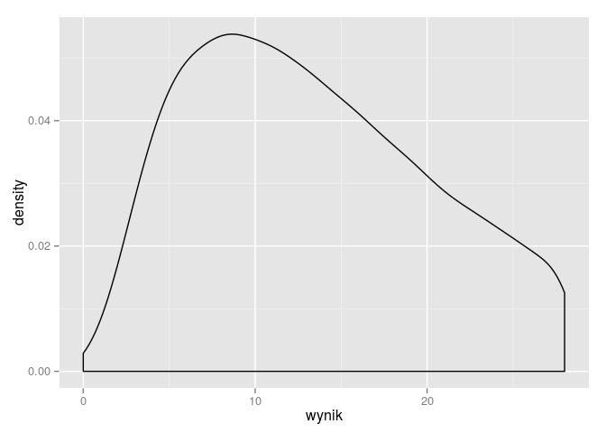

```r
ggplot(gmm14.skala.sumy) +
  aes(x = wynik) +
  geom_density(adjust = 2)
```

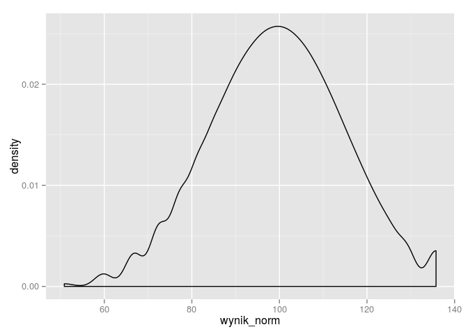

```r
ggplot(gmm14.skala.sumy) +
  aes(x = wynik_norm) +
  geom_density(adjust = 2)
```

# Pomijanie uczniów przystępujących do egzaminu po raz kolejny

Czasami (w wypadku EWD na ogół) interesować mogą nas tylko uczniowie piszący dany egzamin po raz pierwszy (na wyjściu) lub ostatni (na wejściu).

Do ich odfiltrowywania służy funkcja `filtruj_przystapienia()`. Dla wskazanego *rodzaju egzaminu* (lub tylko dla wybranej *części egzaminu*) oraz określenia z jakiego źródła (CKE/OKE) mają pochodzić dane, zwraca ona zbiór zawierający jedynie pierwsze lub ostatnie przystąpienia uczniów do danego egzaminu. Za pomocą złączenia *inner_join* lub filtrowania *semi_join* można dzięki nim odfiltrować pożądane wyniki egzaminu lub oszacowania umiejętności uczniów.

Np. złączmy przygotowane powyżej sumy punktów z informacjami o pierwszym przystąpieniu do egzaminu gimnazjalnego.

- sprawdzając przystąpienia tylko w obrębie części egzaminu *matematyka*
- sprawdzając przystąpienia w obrębie całego egzaminu gimnazjalnego

(W obydwu wypadkach dla *danych EWD*, bo właśnie na takich danych mamy policzone sumy punktów)

```r
# uwaga - wykonywanie tego polecenia może zająć kilka minut
filtrMat = filtruj_przystapienia(src, TRUE, 'egzamin gimnazjalny', 'matematyka', TRUE) %>%
  collect()
# uwaga - wykonywanie tego polecenia może zająć kilka minut
filtrGim = filtruj_przystapienia(src, TRUE, 'egzamin gimnazjalny', NULL, TRUE) %>%
  collect()
head(filtrMat)
```

```
## Source: local data frame [6 x 5]
##
##   id_obserwacji dane_ewd     rodzaj_egzaminu czesc_egzaminu  rok
## 1      16035244     TRUE egzamin gimnazjalny     matematyka 2014
## 2      15947372     TRUE egzamin gimnazjalny     matematyka 2014
## 3      15785410     TRUE egzamin gimnazjalny     matematyka 2014
## 4       2949104     TRUE egzamin gimnazjalny     matematyka 2012
## 5       3079171     TRUE egzamin gimnazjalny     matematyka 2012
## 6       3322878     TRUE egzamin gimnazjalny     matematyka 2013
```

```r
# filtrujemy
gmm14.filtrMat = gmm14.sz.sumy %>%
  inner_join(filtrMat)
gmm14.filtrGim = gmm14.sz.sumy %>%
  inner_join(filtrGim)
# jaka jest różnica w liczbie obserwacji?
nrow(gmm14.filtrMat) - nrow(gmm14.filtrGim)
```

```
## [1] 128
```

Czy umiemy powiedzieć, z czego wynika różnica w liczbie obserwacji pomiędzy jednym i drugim sposobem filtrowania?

# Złączanie danych pomiędzy egzaminami

Na wstępie warto zaznaczyć, że **nie wszystkie wyniki egzaminacyjne i oszacowania umiejętności uczniów są łączliwe między latami**. Szczegółowa rozpiska znajduje się pod adresem http://zpd.ibe.edu.pl/doku.php?id=obazie

Tak, czy owak, złączanie następuje wprost po *id_obserwacji* (i co najwyżej nic się nie połączy).

Warto jeszcze zauważyć, że złączane zbiory mogą zawierać jednakowo nazywające się kolumny (np. *wynik*, *dysleksja*, itp.), które przed złączeniem należy przezwać (np. na *wynik_spr*, *wynik_gh*, *dysleksja_spr*, *dysleksja_gh* itd.).

```r
# przyłączmy do policzonych sum surowych punktów z egzaminu GMM 2014 wyniki sprawdzianu 2011

# pobierzmy wyniki sprawdzianu 2011 z danych EWD
#   uwaga - wykonywanie tego polecenia może zająć kilkanaście minut
spr11 = pobierz_wyniki_egzaminu(src, 'sprawdzian', '', 2011, TRUE) %>%
  collect()
# sumujemy punkty
spr11 = zsumuj_punkty(spr11)
# przezywamy kolumny
spr11 = spr11 %>%
  rename(wynik_spr = wynik, rok_spr = rok, id_testu_spr = id_testu, id_szkoly_spr = id_szkoly)
# złączamy
polaczone = gmm14.sz.sumy %>%
  left_join(spr11)
head(polaczone)
```

```
##   id_obserwacji id_testu id_szkoly  rok wynik wynik_norm id_testu_spr
## 1      17233868     1596     14040 2014     4      77.79           NA
## 2      17233870     1596     14040 2014     5      81.72           NA
## 3      17233871     1596     14040 2014     4      77.79           NA
## 4       3099719     1596     14040 2014     8      90.56           NA
## 5      17233872     1596     14040 2014     6      85.07           NA
## 6      17233875     1596     14053 2014     8      90.56           NA
##   id_szkoly_spr rok_spr wynik_spr
## 1            NA      NA        NA
## 2            NA      NA        NA
## 3            NA      NA        NA
## 4            NA      NA        NA
## 5            NA      NA        NA
## 6            NA      NA        NA
```

```r
# obliczamy, ile wyników się połączyło
polaczone %>%
  group_by(is.na(rok_spr)) %>%
  summarize(n = n())
```

```
## Source: local data frame [2 x 2]
##
##   is.na(rok_spr)      n
## 1          FALSE 335154
## 2           TRUE  27595
```

Jak widać nie przyłączyło się nieco ponad 27 tys. uczniów (np. o opóźnionym toku kształcenia).